# CSE204 - Introduction to Machine Learning - Lab Session 12 - Exam

[CSE204-2021](https://moodle.polytechnique.fr/course/view.php?id=12838) Lab session #12 - Exam

Adrien Ehrhardt

Groupe B

## Quiz

The following function `impute_missing` pertains to the moodle quiz question on Missing Value Imputation (12 points). It is separate from the 'main' lab exercises which follow. Complete the function by replacing `# TODO` tags with your code, according to the instructions given.

```python
import numpy as np
from sklearn.decomposition import PCA
```

```python
def impute_missing(X: np.ndarray, random_number: float = 2.5) -> float:
    """
    Perform PCA missing data imputation

    :param numpy.ndarray X: array with one missing value
    :param float random_number: initialize missing value to this random value
    :return: imputed value
    :rtype: float
    """
    # Identify the row and column of the missing value
    i, j = np.argwhere(np.isnan(X))[0]

    # TODO: Impute 'random_number' to replace the missing value
    ### BEGIN SOLUTION
    X[i, j] = random_number
    ### END SOLUTION

    # TODO: Carry out PCA by completing the code below
    # TODO: Reconstruct X from the main component
    # TODO: Impute the value
    pca = PCA(n_components=2).fit(X)
    U = pca.components_.T
    Lambda = pca.explained_variance_
    ### BEGIN SOLUTION
    w = U[:, 0].reshape(2, 1)
    Xtilde = X @ w @ w.T
    X[i, j] = Xtilde[i, j]
    ### END SOLUTION

    return X[i, j]
```

```python
# Data
X = np.array([
    [-5,-1.5],
    [-3,-3],
    [-1,-0.5],
    [-1,4],
    [np.nan,2],
    [4,4],
    [8,6.5],
    [9,7],
    [9,-3.5],
])


print(impute_missing(X))
```

```
2.765173871509254
```

## Overall presentation

Emphasis is put on the quiz, which will be worth $\approx$ 50 % of this exam's grade.

This lab is composed of 3 exercises, granting up to 3, 3 and 5 points.

There are examples of automatic tests that are run against your code. **They are not exhaustive nor sufficient** (we will run other - hidden - tests), **but they are necessary**: they have to pass, otherwise you can be sure *not* to get the points.

You **cannot** Google anything. The exam is open book w.r.t. the lectures. Some help and hints are provided for each question (e.g. which function to use and how), and you can also use the `help(...)` function and consult the documentation linked in this notebook.

- **Do not** delete any pre-existing cell (you can create and delete your own cells for testing).
- **Do not** change the type (Markdown / Code / ...) of any pre-existing cell.
- Run the notebook with the **CSE204** kernel - if you didn't install it beforehand (come on, it's the $12^{th}$ lab!), proceed at your own risk.
- **Do not** rename the file when uploading your work on Moodle.
- **Do not** edit the notebook's or a cell's metadata.

## Imports

```python
import os
import gc
import json
from copy import deepcopy
import itertools
import pickle
import numpy as np
import pandas as pd
import sklearn as sk
from sklearn.tree import DecisionTreeClassifier
import tensorflow as tf
import tensorflow.keras.datasets.mnist as mnist
from tensorflow.keras.layers import Dense, Input, Conv2D, Activation, Dropout, MaxPooling2D,\
    BatchNormalization, Flatten, UpSampling2D, Reshape
from tensorflow.keras import Model
from tensorflow.keras.optimizers import SGD
from tensorflow.keras.preprocessing import image
import matplotlib.pyplot as plt
```

[output not shown]

## Introduction

In this lab, you will get hands-on experience with Unsupervised Learning, namely dimension reduction using PCA and Undercomplete Autoencoders, as well as Supervised Learning, namely multi-label classification.

The goal of dimension reduction is to find a suitable transformation which converts a high-dimensional space into a smaller feature space, such that the important information is not lost, but the visualization and interpretability are easier.

The goal of supervised multi-label classification is to predict the membership of a sample to **possibly several** categories.

## Dataset

- Get the data

*If* the following cell does not work, *e.g.* on Windows, copy / paste the link to the dataset in your browser and place the downloaded artifact in the same directory as this notebook.

```python
%%bash

if ! [ -f Movie_Poster_Dataset.zip ]; then
    curl -O https://www.cs.ccu.edu.tw/~wtchu/projects/MoviePoster/Movie_Poster_Dataset.zip
fi
```

```python
%%bash

if ! [ -f Movie_Poster_Metadata.zip ]; then
    curl -O https://www.cs.ccu.edu.tw/~wtchu/projects/MoviePoster/Movie_Poster_Metadata.zip
fi
```

- Unzip the data

*If* the following cell does not work, *e.g.* on Windows, unzip the directory using your built-in tools (try double-clicking the zip file).

```python
%%bash

if ! [ -r Movie_Poster_Dataset ]; then
    unzip -o Movie_Poster_Dataset.zip
fi
```

```python
%%bash

if ! [ -r groundtruth ]; then
    unzip -o Movie_Poster_Metadata.zip
fi
```

You should now have folders named `Movie_Poster_Dataset` and `groundtruth` in your working directory containing years of pictures of movie posters and associated metadata (in particular their genre(s)).

- List id's and genres from `groundtruth` to obtain `y` (the categories to predict)

```python
files = []
for year in range(1980, 2016):  # loop through years
    encoding = 'utf-8' if year in [1980, 1981] else 'utf-16'
    with open(f'groundtruth/{year}.txt', 'r', encoding=encoding) as f:  # open metadata file
        file = '[' + f.read() + ']'
        file = file.replace('}', '},')
        file = file.replace('ObjectId(', '')
        file = file.replace('),', ',')
        file = file.replace(',\n]', ']')
        data = json.loads(file)  # read metadata file
        files.append(pd.DataFrame(data)[['imdbID', 'Genre']])  # keep only interesting information
```

```python
genres = pd.concat(files)  # concatenate all years in a single pandas DataFrame
```

```python
# List all genres in the dataset
possible_genres = np.unique(list(itertools.chain.from_iterable(
    genres.Genre.str.split(', ').to_list())))
```

```python
possible_genres
```

```
array(['Action', 'Adult', 'Adventure', 'Animation', 'Biography', 'Comedy',
       'Crime', 'Documentary', 'Drama', 'Family', 'Fantasy', 'Game-Show',
       'History', 'Horror', 'Music', 'Musical', 'Mystery', 'N/A', 'News',
       'Reality-TV', 'Romance', 'Sci-Fi', 'Short', 'Sport', 'Talk-Show',
       'Thriller', 'War', 'Western'], dtype='<U11')
```

```python
genres.set_index('imdbID', inplace=True)  # set _id as the DataFrame's index
```

```python
# Create one boolean column for each genre and each movie
for genre in possible_genres:
    genres[genre] = genres.Genre.str.contains(genre) * 1
```

```python
genres.drop(columns="Genre", inplace=True)
genres = genres[~genres.index.duplicated(keep='first')]
genres
```

| imdbID | Action | Adult | Adventure | Animation | Biography | Comedy | Crime | Documentary | Drama | Family | ... | News | Reality-TV | Romance | Sci-Fi | Short | Sport | Talk-Show | Thriller | War | Western |
| --- | --- | --- | --- | --- | --- | --- | --- | --- | --- | --- | --- | --- | --- | --- | --- | --- | --- | --- | --- | --- | --- |
| tt0080684 | 1 | 0 | 1 | 0 | 0 | 0 | 0 | 0 | 0 | 0 | ... | 0 | 0 | 0 | 0 | 0 | 0 | 0 | 0 | 0 | 0 |
| tt0081562 | 0 | 0 | 0 | 0 | 0 | 1 | 1 | 0 | 0 | 0 | ... | 0 | 0 | 0 | 0 | 0 | 0 | 0 | 0 | 0 | 0 |
| tt0080339 | 0 | 0 | 0 | 0 | 0 | 1 | 0 | 0 | 0 | 0 | ... | 0 | 0 | 0 | 0 | 0 | 0 | 0 | 0 | 0 | 0 |
| tt0080377 | 1 | 0 | 0 | 0 | 0 | 1 | 0 | 0 | 0 | 0 | ... | 0 | 0 | 0 | 0 | 0 | 0 | 0 | 0 | 0 | 0 |
| tt0081375 | 0 | 0 | 0 | 0 | 0 | 1 | 0 | 0 | 0 | 0 | ... | 0 | 0 | 0 | 0 | 0 | 0 | 0 | 0 | 1 | 0 |
| ... | ... | ... | ... | ... | ... | ... | ... | ... | ... | ... | ... | ... | ... | ... | ... | ... | ... | ... | ... | ... | ... |
| tt2912776 | 0 | 0 | 0 | 0 | 0 | 0 | 0 | 0 | 1 | 0 | ... | 0 | 0 | 0 | 0 | 0 | 0 | 0 | 0 | 0 | 0 |
| tt2241750 | 0 | 0 | 0 | 0 | 0 | 0 | 0 | 0 | 1 | 0 | ... | 0 | 0 | 0 | 0 | 0 | 1 | 0 | 0 | 0 | 0 |
| tt4797082 | 0 | 0 | 0 | 0 | 0 | 0 | 0 | 1 | 0 | 0 | ... | 0 | 0 | 0 | 0 | 0 | 0 | 0 | 0 | 0 | 0 |
| tt5350540 | 0 | 0 | 0 | 0 | 0 | 0 | 0 | 1 | 0 | 0 | ... | 0 | 0 | 0 | 0 | 1 | 0 | 0 | 0 | 0 | 0 |
| tt4529904 | 0 | 0 | 0 | 0 | 0 | 1 | 0 | 0 | 0 | 0 | ... | 0 | 0 | 0 | 0 | 0 | 0 | 0 | 0 | 0 | 0 |

8861 rows × 28 columns

- Load images in an array

Beware of the weird double-loop (to go easy on the memory).

```python
def train_test_split(subset: str = "train", max_size=4000):
    if subset == "train":
        start = 0
    else:
        start = 20
    images_loop = []
    images_ids = []
    increment_size = 3
    images = np.zeros((max_size, 200, 200, 3))
    compteur = 0
    for year in range(1980 + start, 1980 + start + 15):
        if year > 2005:
            continue
        print(f'Loading posters from year {year}')
        for filename in os.listdir(f'Movie_Poster_Dataset/{year}'):
            img = image.load_img(f'Movie_Poster_Dataset/{year}/{filename}',
                                 target_size=(200, 200, 3))
            img = image.img_to_array(img)
            img = img / 255
            images[compteur, :, :, :] = img
            images_ids.append(filename.replace('.jpg', ''))
            compteur += 1
    return images[:compteur, :, :, :], np.array(images_ids)
```

```python
# Do not run this several times due to memory leaks
gc.collect()
X_train, indices_train = train_test_split()
```

```
Loading posters from year 1980
Loading posters from year 1981
Loading posters from year 1982
Loading posters from year 1983
Loading posters from year 1984
Loading posters from year 1985
Loading posters from year 1986
Loading posters from year 1987
Loading posters from year 1988
Loading posters from year 1989
Loading posters from year 1990
Loading posters from year 1991
Loading posters from year 1992
Loading posters from year 1993
Loading posters from year 1994
```

First poster:

[figure not shown]

```python
plt.imshow(X_train[0, :, :, :])
plt.axis('off');
```

Get categories:

```python
y_train = genres.loc[genres.index.isin(indices_train)].values
y_train
```

```
array([[1, 0, 1, ..., 0, 0, 0],
       [0, 0, 0, ..., 0, 0, 0],
       [0, 0, 0, ..., 0, 0, 0],
       ...,
       [0, 0, 0, ..., 1, 0, 0],
       [0, 0, 0, ..., 0, 0, 0],
       [0, 0, 0, ..., 0, 0, 0]])
```

```python
X_train.shape, indices_train.shape, y_train.shape
```

```
((2216, 200, 200, 3), (2216,), (2216, 28))
```

```python
X_test, indices_test = train_test_split("test")
```

```
Loading posters from year 2000
Loading posters from year 2001
Loading posters from year 2002
Loading posters from year 2003
Loading posters from year 2004
Loading posters from year 2005
```

```python
y_test = genres.loc[genres.index.isin(indices_test)].values
y_test
```

```
array([[0, 0, 0, ..., 0, 0, 0],
       [0, 0, 1, ..., 0, 0, 0],
       [1, 0, 1, ..., 1, 0, 0],
       ...,
       [0, 0, 0, ..., 0, 0, 0],
       [0, 0, 0, ..., 0, 0, 0],
       [0, 0, 0, ..., 1, 0, 0]])
```

```python
X_test.shape, indices_test.shape, y_test.shape
```

```
((1523, 200, 200, 3), (1523,), (1523, 28))
```

```python
X_train_reshaped = X_train.reshape(X_train.shape[0], np.prod(X_train.shape[1:]))
X_train_reshaped.shape
```

```
(2216, 120000)
```

```python
X_test_reshaped = X_test.reshape(X_test.shape[0], np.prod(X_test.shape[1:]))
X_test_reshaped.shape
```

```
(1523, 120000)
```

## Exercise 1: PCA (3 points)

Complete the following function.

Recall that:

The Singular Value Decomposition of a matrix $X \in R^{n\times p}$ is given as

$$ X = U \Sigma W^T, $$

where $\Sigma \in R^{n\times p}$ is a rectangular diagonal matrix of positive values known as the singular values of $X$ (often denoted by $\sigma(X)$), and $U \in R^{n\times n}$ and $W \in R^{p\times p}$ are orthonormal matrices, which columns are the left and right (respectively) singular vectors of the matrix $X$.

We can reduce the dimensionality of our data by truncating the transformed variables to include only a subset of those variables with the highest variance. For example, if we keep the first `n_components` $\leq p$ variables, the reduced transformation reads

$$ T_{n_{components}} = X W_{n_{components}}. $$

We can then decode to reconstruct the images from the lower-dimensional space. Recall that based on the PCA transformation, we can compute the reconstructed images with

$$ \hat{X} = X W_{n_{components}} W_{n_{components}}^T $$

```python
def transform_PCA(X_train, X_test, n_components: int = 3):
    """
    Learns principal components analysis on X_train, returns the projections of X_train and X_test
    on n_components first principal components and W_n_components.
    :param numpy.ndarray X_train: training set of size n x p
    :param numpy.ndarray X_test: testing set of size m x p
    :param int n_components: number of components to retain in the PCA decomposition
    :return: projection of X_train, X_test and W_n_components from SVD
    """
    ### BEGIN SOLUTION
    _, _, w_transpose = np.linalg.svd(X_train, full_matrices=False)
    W_n_components = w_transpose.T[:, :n_components]
    X_test_transformed = np.matmul(X_test, W_n_components)
    X_train_transformed = np.matmul(X_train, W_n_components)
    ### END SOLUTION
    return X_train_transformed, X_test_transformed, W_n_components
```

```python
X_train_PCA_transformed, X_test_PCA_transformed, W_n_components = transform_PCA(X_train_reshaped, X_test_reshaped)
assert X_test_PCA_transformed.shape[1] == 3
### BEGIN HIDDEN TESTS
assert X_test_PCA_transformed.shape[0] == X_test_reshaped.shape[0]
### END HIDDEN TESTS
```

#### 2D representation

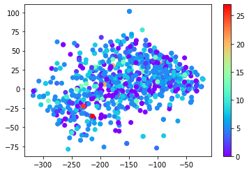

```python
indices = np.random.randint(0, X_test_PCA_transformed.shape[0], 1000)
plt.scatter(X_test_PCA_transformed[indices, 0],
            X_test_PCA_transformed[indices, 1],
            c=np.argmax(y_train[indices, :], axis=1), cmap='rainbow')
plt.colorbar();
```

#### Reconstruction

Complete the following function:

```python
def reconstruct_image(X_transformed: np.ndarray, W: np.ndarray):
    """
    Reconstruct an image from a projection onto n_components
    """
    ### BEGIN SOLUTION
    return np.matmul(X_transformed, W.T)
    ### END SOLUTION
```

```python
new_data = reconstruct_image(X_test_PCA_transformed[:5, :], W_n_components)
assert new_data.shape == (5, 200 * 200 * 3)
```

[output not shown]

[figure not shown]

```python
fig, ax = plt.subplots(2, 5)
for i in range(5):
    ax[0, i].imshow(X_test[i, :])
    ax[0, i].set_axis_off()
    ax[1, i].imshow(new_data[i, :].reshape(200, 200, 3))
    ax[1, i].set_axis_off()
```

## Exercise 2: Convolutional Autoencoders (3 points)

Complete the following function by adding:

- An encoder with:
  - An [`Input`](https://keras.io/api/layers/core_layers/input/) layer of `shape` `input_size`;
  - A [`Conv2D`](https://keras.io/api/layers/convolution_layers/convolution2d/) layer of 16 3x3 filters for each channel, with `same` padding and `relu` activation;
  - A [`MaxPooling2D`](https://keras.io/api/layers/pooling_layers/max_pooling2d/) layer of 4x4 `pool_size` with `same padding`;
  - A [`Conv2D`](https://keras.io/api/layers/convolution_layers/convolution2d/) layer of 2 3x3 filters for each channel, with `same` padding and `relu` activation;
  - A [`MaxPooling2D`](https://keras.io/api/layers/pooling_layers/max_pooling2d/) layer of 4x4 `pool_size` with `same padding`;
  - A [`Flatten`](https://keras.io/api/layers/reshaping_layers/flatten/) layer;
  - A [`Dense`](https://keras.io/api/layers/core_layers/dense/) layer with `code_size` nodes;
- A decoder with:
  - A [`Dense`](https://keras.io/api/layers/core_layers/dense/) layer with 338 nodes;
  - A [`Reshape`](https://keras.io/api/layers/reshaping_layers/reshape/) layer with `target_shape` of `(13, 13, 2)`;
  - A [`Conv2D`](https://keras.io/api/layers/convolution_layers/convolution2d/) layer of 2 3x3 filters for each channel, with `same` padding and `relu` activation;
  - An [`UpSampling2D`](https://keras.io/api/layers/reshaping_layers/up_sampling2d/) layer with `size` 4x4;
  - A [`Conv2D`](https://keras.io/api/layers/convolution_layers/convolution2d/) layer of 16 3x3 filters for each channel, with `relu` activation;
  - An [`UpSampling2D`](https://keras.io/api/layers/reshaping_layers/up_sampling2d/) layer with `size` 4x4;
  - A [`Conv2D`](https://keras.io/api/layers/convolution_layers/convolution2d/) layer of 1 3x3 filters for each channel, with `same` padding and `sigmoid` activation.
- [Compile](https://keras.io/api/models/model_training_apis/) the resulting autoencoder with optimizer `Adam` and `mean_square_error` loss;
- Return the autoencoder and the encoder.

```python
def convolutional_autoencoder(input_size, code_size: int):
    """
    Instanciate and compiles an autoencoder, returns both the autoencoder and just the encoder

    :param tuple input_size: shape of the input samples
    :param int code_size: size of the new representation space
    :return: autoencoder, encoder
    """
    ### BEGIN SOLUTION
    # Build the autoencoder
    input_layer = Input(shape=input_size)
    conv2d_1st_layer = Conv2D(16, (3, 3), padding='same', activation='relu')(input_layer)
    max_pooling_1st_layer = MaxPooling2D(pool_size=(4, 4), padding='same')(conv2d_1st_layer)
    conv2d_2nd_layer = Conv2D(2, (3, 3), padding='same', activation='relu')(max_pooling_1st_layer)
    max_pooling_2nd_layer = MaxPooling2D(pool_size=(4, 4), padding='same')(conv2d_2nd_layer)
    flatten_layer = Flatten()(max_pooling_2nd_layer)
    code_layer = Dense(code_size)(flatten_layer)

    decode_layer = Dense(13 * 13 * 2)(code_layer)
    reshaped_layer = Reshape((13, 13, 2))(decode_layer)
    conv2d_3rd_layer = Conv2D(2, (3, 3), activation='relu', padding='same')(reshaped_layer)
    upsample_1st_layer = UpSampling2D((4, 4))(conv2d_3rd_layer)
    conv2d_4th_layer = Conv2D(16, (3, 3), activation='relu')(upsample_1st_layer)
    upsample_2nd_layer = UpSampling2D((4, 4))(conv2d_4th_layer)
    output_layer = Conv2D(1, (3, 3), activation='sigmoid', padding='same')(upsample_2nd_layer)

    # Compile the model
    autoencoder = Model(input_layer, output_layer)
    autoencoder.compile(optimizer='Adam', loss='mean_squared_error')

    # Also provide just the encoder model
    encoder = Model(input_layer, code_layer)
    ### END SOLUTION
    return autoencoder, encoder
```

```python
cnn_autoencoder, cnn_encoder = convolutional_autoencoder(X_train.shape[1:], 3)
### BEGIN HIDDEN TESTS
assert len(cnn_autoencoder.layers) >= 14
### END HIDDEN TESTS
```

[output not shown]

The following cell trains the convolutional autoencoder; it is quite long to run. If you're confident about your code, you might want to skip this and go to the next section, coming back here when necessary / when you're done. You **can** also train on fewer examples / less epochs (modify the cell below) to speed things up and debug your code.

```
2022-05-01 18:54:50.870288: W tensorflow/core/framework/cpu_allocator_impl.cc:82] Allocation of 1063680000 exceeds 10% of free system memory.
2022-05-01 18:54:51.751636: W tensorflow/core/framework/cpu_allocator_impl.cc:82] Allocation of 1063680000 exceeds 10% of free system memory.
```

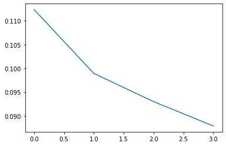

```python
history = cnn_autoencoder.fit(X_train, X_train, epochs=4)
plt.plot(history.history['loss']);
```

```
2022-05-01 18:57:08.146893: W tensorflow/core/framework/cpu_allocator_impl.cc:82] Allocation of 1063680000 exceeds 10% of free system memory.
2022-05-01 18:57:12.162380: W tensorflow/core/framework/cpu_allocator_impl.cc:82] Allocation of 731040000 exceeds 10% of free system memory.
```

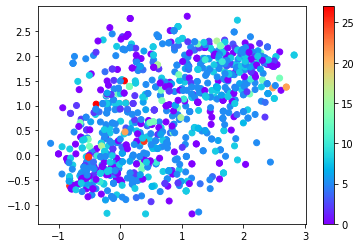

```python
X_train_transformed_autoencoder = cnn_encoder.predict(X_train)
X_test_transformed_autoencoder = cnn_encoder.predict(X_test)
indices = np.random.randint(0, X_test_transformed_autoencoder.shape[0], 1000)
plt.scatter(X_test_transformed_autoencoder[indices, 0],
            X_test_transformed_autoencoder[indices, 1],
            c=np.argmax(y_train[indices, :], axis=1), cmap='rainbow')
plt.colorbar();
```

[figure not shown]

```python
fig, ax = plt.subplots(2, 5)
new_data = cnn_autoencoder.predict(X_test[:6, :])

for i in range(5):
    ax[0, i].imshow(X_test[i, :])
    ax[1, i].imshow(new_data[i, :])
    ax[0, i].set_axis_off()
    ax[1, i].set_axis_off()
```

## Exercise 3: Classification (5 points)

### Using reduced representation and tree-based methods

To predict the genres of each movie given its poster, we will use a binary classification model, such as a decision tree, **for each label**.

Complete the following function.

*Hint*

- it should return *e.g.* `{'Action': DecisionTreeClassifier(model_kwargs), ...}`;
- you can use `**model_kwargs` to "unpack" a dictionary.

```python
def dict_of_binary_models(labels, model, model_kwargs):
    """
    Constructs a dict with key label and instanciate and object of class model as value.

    :param list labels: list of labels of genres
    :param model: a model Class from sklearn
    :param dict model_args: a dictionary of arguments to pass to the model instanciation
    :return: a dict which key is the label and which value is a new instance of model
    """
    ### BEGIN SOLUTION
    return {label: model(**model_kwargs) for label in labels}
    ### END SOLUTION
```

```python
dict_of_models = dict_of_binary_models(genres.columns.to_list(),
                                       DecisionTreeClassifier,
                                       {'max_depth': 5})
```

```python
[print(key, ':', value) for key, value in dict_of_models.items()]
assert len(dict_of_models) == len(genres.columns.to_list())
### BEGIN HIDDEN TESTS
assert np.all([el.__class__ == sk.tree._classes.DecisionTreeClassifier for el in dict_of_models.values()])
### END HIDDEN TESTS
```

```
Action : DecisionTreeClassifier(max_depth=5)
Adult : DecisionTreeClassifier(max_depth=5)
Adventure : DecisionTreeClassifier(max_depth=5)
Animation : DecisionTreeClassifier(max_depth=5)
Biography : DecisionTreeClassifier(max_depth=5)
Comedy : DecisionTreeClassifier(max_depth=5)
Crime : DecisionTreeClassifier(max_depth=5)
Documentary : DecisionTreeClassifier(max_depth=5)
Drama : DecisionTreeClassifier(max_depth=5)
Family : DecisionTreeClassifier(max_depth=5)
Fantasy : DecisionTreeClassifier(max_depth=5)
Game-Show : DecisionTreeClassifier(max_depth=5)
History : DecisionTreeClassifier(max_depth=5)
Horror : DecisionTreeClassifier(max_depth=5)
Music : DecisionTreeClassifier(max_depth=5)
Musical : DecisionTreeClassifier(max_depth=5)
Mystery : DecisionTreeClassifier(max_depth=5)
N/A : DecisionTreeClassifier(max_depth=5)
News : DecisionTreeClassifier(max_depth=5)
Reality-TV : DecisionTreeClassifier(max_depth=5)
Romance : DecisionTreeClassifier(max_depth=5)
Sci-Fi : DecisionTreeClassifier(max_depth=5)
Short : DecisionTreeClassifier(max_depth=5)
Sport : DecisionTreeClassifier(max_depth=5)
Talk-Show : DecisionTreeClassifier(max_depth=5)
Thriller : DecisionTreeClassifier(max_depth=5)
War : DecisionTreeClassifier(max_depth=5)
Western : DecisionTreeClassifier(max_depth=5)
```

Complete the following function which calls `fit` of each model in the dictionary with the appropriate data.

```python
def train_binary_models(dict_of_models: dict, X_train: np.ndarray, y_train: np.ndarray):
    """
    Trains each specific model (to a given label) with the appropriate training data / labels.

    :param dict dict_of_models: a dictionary (key: class labels, values: sklearn models)
    :param numpy.ndarray X_train: training dataset
    :param numpy.ndarray y_train: one-hot encoded labels of training dataset (of size n x number of labels)
    """
    for index, label in enumerate(dict_of_models.keys()):
        dict_of_models[label].fit(X=X_train, y=y_train[:, index])
```

```python
train_binary_models(dict_of_models, X_train_PCA_transformed, y_train)
```

```python
for label in dict_of_models.keys():
    assert hasattr(dict_of_models[label], "classes_")
```

Complete the following function which predicts each label on `X_test`.

```python
def pred_binary_models(dict_of_models: dict, X_test: np.ndarray):
    """
    Applies predict method for each classifier on X_test

    :param dict dict_of_models: a dictionary (key: class labels, values: sklearn trained models)
    :param numpy.ndarray X_test: testing dataset
    :returns: a dictionary (key: class labels, values: np.ndarray of binary class prediction)
    """
    ### BEGIN SOLUTION
    return {label: model.predict(X_test) for label, model in dict_of_models.items()}
    ### END SOLUTION
```

```python
dict_of_predictions = pred_binary_models(dict_of_models, X_test_PCA_transformed)
```

```python
[print(key, ':', value) for key, value in dict_of_predictions.items()];
### BEGIN HIDDEN TESTS
for label in dict_of_predictions.keys():
    assert np.all((dict_of_predictions[label] == 1) | (dict_of_predictions[label] == 0))
### END HIDDEN TESTS
```

```
Action : [0 0 0 ... 0 0 0]
Adult : [0 0 0 ... 0 0 0]
Adventure : [0 0 0 ... 0 0 0]
Animation : [0 0 0 ... 0 0 0]
Biography : [0 0 0 ... 0 0 0]
Comedy : [0 1 0 ... 0 0 0]
Crime : [0 0 0 ... 0 0 0]
Documentary : [0 0 0 ... 0 0 0]
Drama : [1 1 1 ... 1 1 0]
Family : [0 0 0 ... 0 0 0]
Fantasy : [0 0 0 ... 0 0 0]
Game-Show : [0 0 0 ... 0 0 0]
History : [0 0 0 ... 0 0 0]
Horror : [0 0 0 ... 0 0 0]
Music : [0 0 0 ... 0 0 0]
Musical : [0 0 0 ... 0 0 0]
Mystery : [0 0 0 ... 0 0 0]
N/A : [0 0 0 ... 0 0 0]
News : [0 0 0 ... 0 0 0]
Reality-TV : [0 0 0 ... 0 0 0]
Romance : [0 0 0 ... 0 0 0]
Sci-Fi : [0 0 0 ... 0 0 0]
Short : [0 0 0 ... 0 0 0]
Sport : [0 0 0 ... 0 0 0]
Talk-Show : [0 0 0 ... 0 0 0]
Thriller : [0 0 0 ... 0 0 0]
War : [0 0 0 ... 0 0 0]
Western : [0 0 0 ... 0 0 0]
```

Complete the following function which computes the error rate for each label.

```python
def dict_of_error_rate(dict_of_predictions, y_test):
    """
    Computes the error rate on X_test for each label given true labels y_test

    :param dict dict_of_predictions: a dictionary (key: class labels, values: np.ndarray of binary class prediction)
    :param numpy.ndarray y_test: testing labels
    :returns: a dictionary (key: class labels, values: 0 <= float <= 1 corresponding to the error rate)
    """
    dict_of_error_rate = {}
    for index, label in enumerate(dict_of_models.keys()):
        dict_of_error_rate[label] = np.sum(np.abs(y_test[:, index] - dict_of_predictions[label])) / y_test.shape[0]
    return dict_of_error_rate
```

```python
dict_of_error_rate_pca = dict_of_error_rate(dict_of_predictions, y_test)
```

```python
[print(key, ':', value) for key, value in dict_of_error_rate_pca.items()];
### BEGIN HIDDEN TESTS
for label in dict_of_error_rate_pca.keys():
    assert 0 <= dict_of_error_rate_pca[label] <= 1
### END HIDDEN TESTS
```

```
Action : 0.17793827971109652
Adult : 0.0
Adventure : 0.13591595535128037
Animation : 0.04136572554169402
Biography : 0.05975049244911359
Comedy : 0.41628365068942874
Crime : 0.16940249507550886
Documentary : 0.0958634274458306
Drama : 0.49967170059093896
Family : 0.061720288903479976
Fantasy : 0.061720288903479976
Game-Show : 0.0
History : 0.034143138542350626
Horror : 0.06106369008535785
Music : 0.07485226526592252
Musical : 0.026263952724885097
Mystery : 0.07747866053841103
N/A : 0.003282994090610637
News : 0.0
Reality-TV : 0.0
Romance : 0.22521339461588968
Sci-Fi : 0.048588312541037425
Short : 0.005252790544977019
Sport : 0.034143138542350626
Talk-Show : 0.0
Thriller : 0.1221273801707157
War : 0.025607353906762966
Western : 0.006565988181221274
```

Let's rerun the whole thing with the convolutional autoencoder approach:

```python
dict_of_models = dict_of_binary_models(genres.columns.to_list(),
                                       DecisionTreeClassifier,
                                       {'max_depth': 5})
train_binary_models(dict_of_models, X_train_transformed_autoencoder, y_train)
for label in dict_of_models.keys():
    assert hasattr(dict_of_models[label], "classes_")
dict_of_predictions = pred_binary_models(dict_of_models, X_test_transformed_autoencoder)
[print(key, ':', value) for key, value in dict_of_predictions.items()];
print('\n')
### BEGIN HIDDEN TESTS
for label in dict_of_predictions.keys():
    assert np.all((dict_of_predictions[label] == 1) | (dict_of_predictions[label] == 0))
### END HIDDEN TESTS
dict_of_error_rate_autoencoder = dict_of_error_rate(dict_of_predictions, y_test)
[print(key, ':', value) for key, value in dict_of_error_rate_autoencoder.items()];
### BEGIN HIDDEN TESTS
for label in dict_of_error_rate_autoencoder.keys():
    assert 0 <= dict_of_error_rate_autoencoder[label] <= 1
### END HIDDEN TESTS
```

```
Action : [0 0 0 ... 0 0 0]
Adult : [0 0 0 ... 0 0 0]
Adventure : [0 0 0 ... 0 0 0]
Animation : [0 0 0 ... 0 0 0]
Biography : [0 0 0 ... 0 0 0]
Comedy : [0 0 0 ... 0 1 0]
Crime : [0 0 0 ... 0 0 0]
Documentary : [0 0 0 ... 0 0 0]
Drama : [0 0 1 ... 0 1 0]
Family : [0 0 0 ... 0 0 0]
Fantasy : [0 0 0 ... 0 0 0]
Game-Show : [0 0 0 ... 0 0 0]
History : [0 0 0 ... 0 0 0]
Horror : [0 0 0 ... 0 0 0]
Music : [0 0 0 ... 0 0 0]
Musical : [0 1 0 ... 0 0 0]
Mystery : [0 0 0 ... 0 0 0]
N/A : [0 0 0 ... 0 0 0]
News : [0 0 0 ... 0 0 0]
Reality-TV : [0 0 0 ... 0 0 0]
Romance : [0 0 0 ... 0 0 0]
Sci-Fi : [0 0 0 ... 0 0 0]
Short : [0 0 0 ... 0 0 0]
Sport : [0 0 0 ... 0 0 0]
Talk-Show : [0 0 0 ... 0 0 0]
Thriller : [0 0 0 ... 0 0 0]
War : [0 0 0 ... 0 0 0]
Western : [0 0 0 ... 0 0 0]


Action : 0.18122127380170716
Adult : 0.0
Adventure : 0.13788575180564674
Animation : 0.03742613263296126
Biography : 0.061720288903479976
Comedy : 0.43795141168745894
Crime : 0.1799080761654629
Documentary : 0.09783322390019698
Drama : 0.4970453053184504
Family : 0.06303348653972422
Fantasy : 0.06106369008535785
Game-Show : 0.0
History : 0.03545633617859488
Horror : 0.06369008535784636
Music : 0.07747866053841103
Musical : 0.030860144451739988
Mystery : 0.07419566644780039
N/A : 0.003282994090610637
News : 0.0
Reality-TV : 0.0
Romance : 0.22455679579776758
Sci-Fi : 0.0479317137229153
Short : 0.005252790544977019
Sport : 0.03939592908732764
Talk-Show : 0.0
Thriller : 0.11950098489822718
War : 0.024294156270518712
Western : 0.011818778726198293
```

```python
error_rates = pd.DataFrame([dict_of_error_rate_pca, dict_of_error_rate_autoencoder],
                           index=['PCA', 'Autoencoder']).T
error_rates
```

|  | PCA | Autoencoder |
| --- | --- | --- |
| Action | 0.177938 | 0.181221 |
| Adult | 0.000000 | 0.000000 |
| Adventure | 0.135916 | 0.137886 |
| Animation | 0.041366 | 0.037426 |
| Biography | 0.059750 | 0.061720 |
| Comedy | 0.416284 | 0.437951 |
| Crime | 0.169402 | 0.179908 |
| Documentary | 0.095863 | 0.097833 |
| Drama | 0.499672 | 0.497045 |
| Family | 0.061720 | 0.063033 |
| Fantasy | 0.061720 | 0.061064 |
| Game-Show | 0.000000 | 0.000000 |
| History | 0.034143 | 0.035456 |
| Horror | 0.061064 | 0.063690 |
| Music | 0.074852 | 0.077479 |
| Musical | 0.026264 | 0.030860 |
| Mystery | 0.077479 | 0.074196 |
| N/A | 0.003283 | 0.003283 |
| News | 0.000000 | 0.000000 |
| Reality-TV | 0.000000 | 0.000000 |
| Romance | 0.225213 | 0.224557 |
| Sci-Fi | 0.048588 | 0.047932 |
| Short | 0.005253 | 0.005253 |
| Sport | 0.034143 | 0.039396 |
| Talk-Show | 0.000000 | 0.000000 |
| Thriller | 0.122127 | 0.119501 |
| War | 0.025607 | 0.024294 |
| Western | 0.006566 | 0.011819 |

### Using CNNs

If the goal is first and foremost to predict the probable genre, why not use directly a CNN with a classification layer!

Complete the following function by adding:

```python
def cnn_model(input_shape: tuple, num_classes: int):
    """
    Returns a compiled keras Conv2D model

    :param tuple input_shape: shape of ONE example as passed to the first layer
    :param int num_classes: number of output classes as passed to the last layer
    """
    model = tf.keras.models.Sequential()
    # model.add(...)
    ### BEGIN SOLUTION
    model.add(Conv2D(32, (3, 3), padding='same', input_shape=input_shape))
    model.add(Activation('relu'))
    model.add(Conv2D(32, (3, 3)))
    model.add(Activation('relu'))
    model.add(MaxPooling2D(pool_size=(4, 4)))

    model.add(Conv2D(32, (3, 3), padding='same'))
    model.add(Activation('relu'))
    model.add(Conv2D(32, (3,3)))
    model.add(Activation('relu'))
    model.add(MaxPooling2D(pool_size=(4, 4)))

    model.add(Flatten())
    model.add(Dense(512))
    model.add(Activation('relu'))
    model.add(Dense(num_classes))
    model.add(Activation('sigmoid'))

    sgd = SGD(lr=0.1, decay=1.0e-6)
    ### END SOLUTION
    # model.compile(...)
    ### BEGIN SOLUTION
    model.compile(loss='binary_crossentropy', optimizer=sgd, metrics=['accuracy'])
    ### END SOLUTION
    return model
```

```python
model = cnn_model(X_train.shape[1:], y_train.shape[1])
```

```python
### BEGIN HIDDEN TESTS
assert len(model.layers) >= 14
### END HIDDEN TESTS
```

```
2022-05-01 18:57:19.413138: W tensorflow/core/framework/cpu_allocator_impl.cc:82] Allocation of 1063680000 exceeds 10% of free system memory.
```

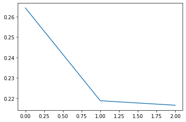

```python
early_stopping = tf.keras.callbacks.EarlyStopping(
    monitor='val_accuracy', min_delta=0, patience=2, mode='auto')

history = model.fit(X_train, y_train, batch_size=32, epochs=5,
    validation_data=(X_test, y_test), shuffle=True, callbacks=[early_stopping])

plt.plot(history.history['loss']);
```

```python
# Predict probabilities for each class on X_test
predictions_cnn = model.predict(X_test)
```

```python
# Convert probabilities into decisions (class membership) with 0.5 threshold
cnn_decisions = (predictions_cnn > 0.5) * 1
```

```python
# Compute error rates per class
error_rates_cnn = np.sum(np.abs(y_test - cnn_decisions), axis=0) / y_test.shape[0]
```

```python
# Add to PCA and Autoencoder error rates and display
error_rates['CNN'] = error_rates_cnn
error_rates
```

|  | PCA | Autoencoder | CNN |
| --- | --- | --- | --- |
| Action | 0.177938 | 0.181221 | 0.175968 |
| Adult | 0.000000 | 0.000000 | 0.000000 |
| Adventure | 0.135916 | 0.137886 | 0.130663 |
| Animation | 0.041366 | 0.037426 | 0.036770 |
| Biography | 0.059750 | 0.061720 | 0.059750 |
| Comedy | 0.416284 | 0.437951 | 0.411687 |
| Crime | 0.169402 | 0.179908 | 0.169402 |
| Documentary | 0.095863 | 0.097833 | 0.094550 |
| Drama | 0.499672 | 0.497045 | 0.495732 |
| Family | 0.061720 | 0.063033 | 0.060407 |
| Fantasy | 0.061720 | 0.061064 | 0.057781 |
| Game-Show | 0.000000 | 0.000000 | 0.000000 |
| History | 0.034143 | 0.035456 | 0.030860 |
| Horror | 0.061064 | 0.063690 | 0.059094 |
| Music | 0.074852 | 0.077479 | 0.074196 |
| Musical | 0.026264 | 0.030860 | 0.024294 |
| Mystery | 0.077479 | 0.074196 | 0.070256 |
| N/A | 0.003283 | 0.003283 | 0.003283 |
| News | 0.000000 | 0.000000 | 0.000000 |
| Reality-TV | 0.000000 | 0.000000 | 0.000000 |
| Romance | 0.225213 | 0.224557 | 0.216021 |
| Sci-Fi | 0.048588 | 0.047932 | 0.043992 |
| Short | 0.005253 | 0.005253 | 0.005253 |
| Sport | 0.034143 | 0.039396 | 0.033487 |
| Talk-Show | 0.000000 | 0.000000 | 0.000000 |
| Thriller | 0.122127 | 0.119501 | 0.114248 |
| War | 0.025607 | 0.024294 | 0.023638 |
| Western | 0.006566 | 0.011819 | 0.005909 |